# Preliminary analysis 3 rust test 1

The third step of prelim analysis

Firza Riany

8/21/2020

# 1 Description

The rust test was conducted in the Rust Lab INRAE Orléans during the period 15 - 30 July 2020. This script is intended for a preliminary analysis before proceeding to association modeling and reaction norm modeling under the project **B4EST WP 3: Black poplar/rust pathosystem.**

Previous steps have been conducted to see:  
1. Verify the pathotype of the strains (for each strain).  
2. Check the incompatible genotypes.  
3. Understand the global distribution of each phenotype.  
4. Understand the variability in distribution of the phenotypes for each strain.  
5. Observe the trait mean across blocks (Genotypic mean) and genotypes (Block mean).  
6. Graphical inspection of genotypic mean across block.

# 2 Objectives

This step 3 is to:  
1. Visualize the experimental plot in the lab.  
2. Adjust the phenotypic values after eliminating block effects.

# 3 Input

```r
load(file = "prelim_step2.RData")  # RData prepared from prelim analysis step 2
```

# 4 Libraries

```r
library(ggplot2)  # To map the experimental design
library(breedR)  # To model the source of phenotypic variation
```

# 5 Visualizing the experimental plot in the lab

The genotypes were placed in the growth chamber with specialized coordinate positions.  
The experimental design is as follows:  
* 3 strains were used as ‘treatments’  
* 168 genotypes were used for each strain  
* 168 genotypes x 3 strains were replicated in 5 blocks

## 5.1 Strain 09AX27

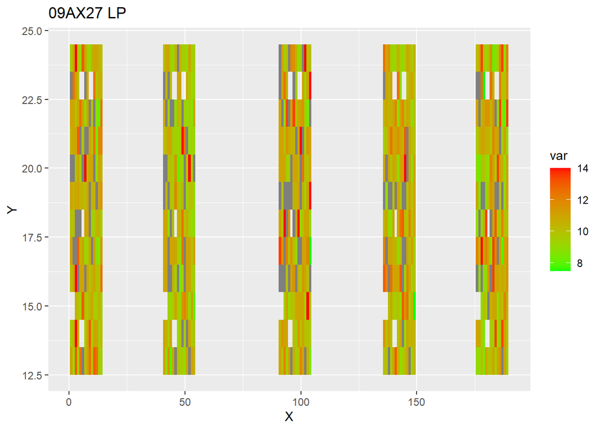

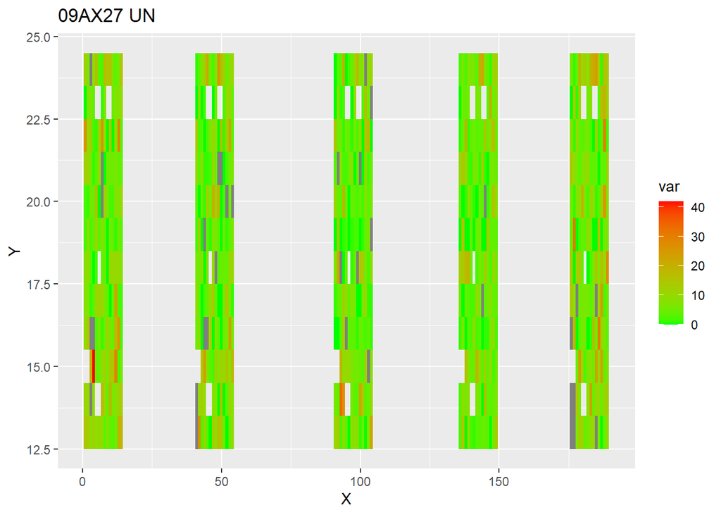

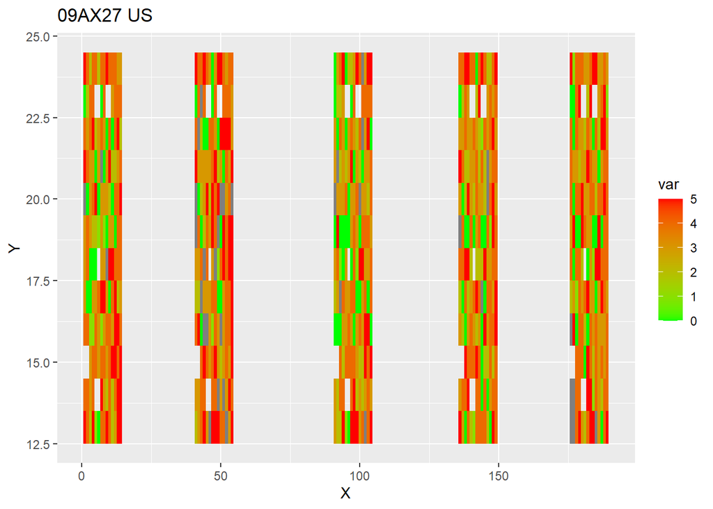

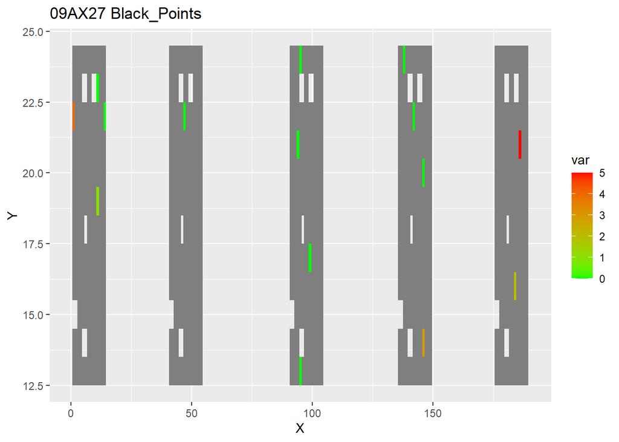

```r
loop.vector <- 1:4  # creating the length of loop sequence

for (i in loop.vector){  # for phenotype i in length
  var <- s09AX27_loop[,i]  # storing the phenotypes in object var
  title <- names(s09AX27_loop[i])  # preparing the title for plot title
  plot <- qplot(X, Y, fill = var, geom = "tile", main = paste("09AX27", title),   # fill is based on variation in phenotypes
                data = s09AX27_clean, xlab = "X", ylab = "Y") +
    scale_fill_gradient(low = "green", high = "red")
  print(plot)
}
```

## 5.2 Strain 93JE3

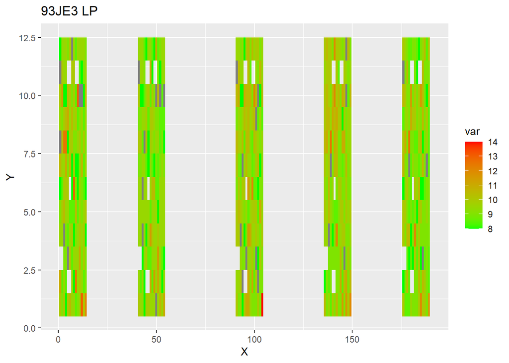

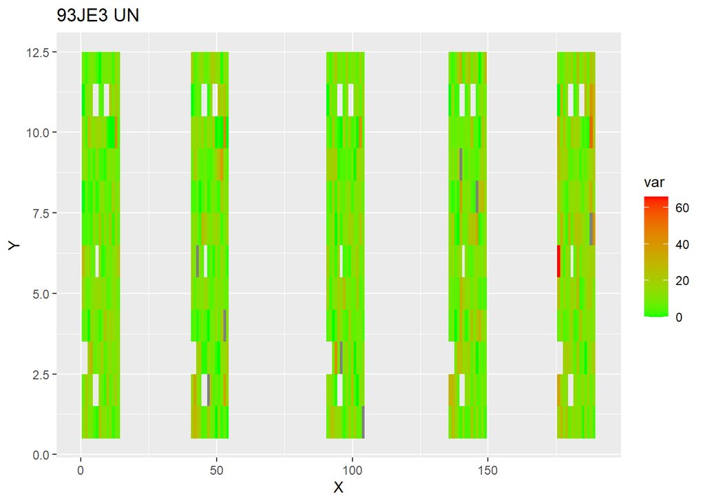

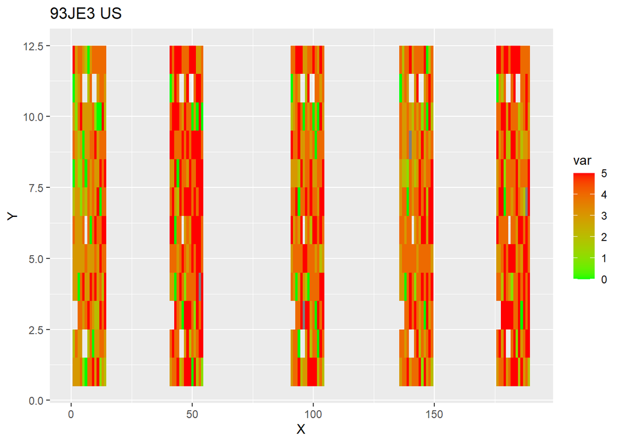

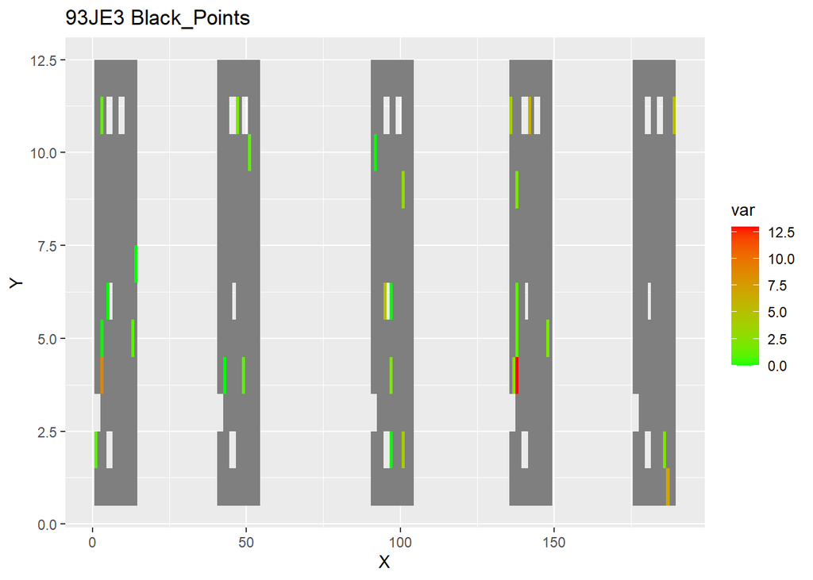

```r
for (i in loop.vector){
  var <- s93JE3_loop[,i]
  title <- names(s93JE3_loop[i])
  plot2 <- qplot(X, Y, fill = var, geom = "tile", main = paste("93JE3", title),
                data = s93JE3_clean, xlab = "X", ylab = "Y") +
    scale_fill_gradient(low = "green", high = "red")
  print(plot2)
}
```

## 5.3 Strain P72

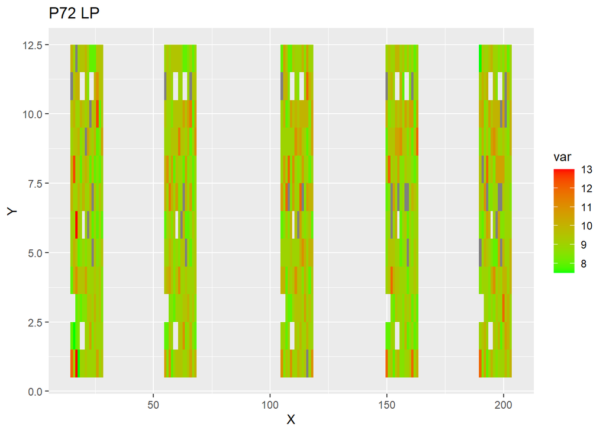

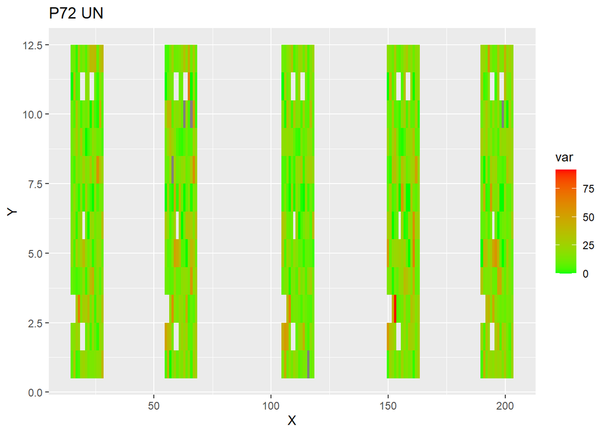

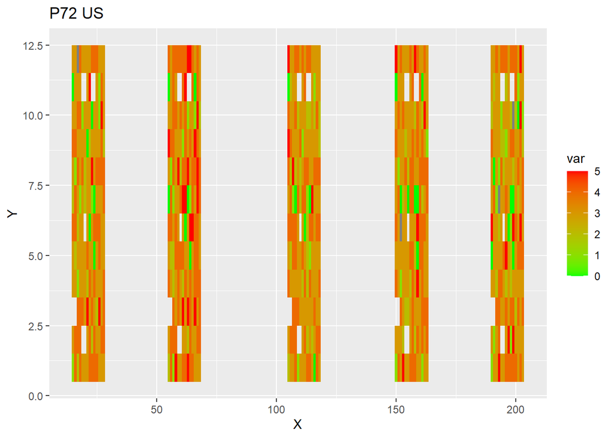

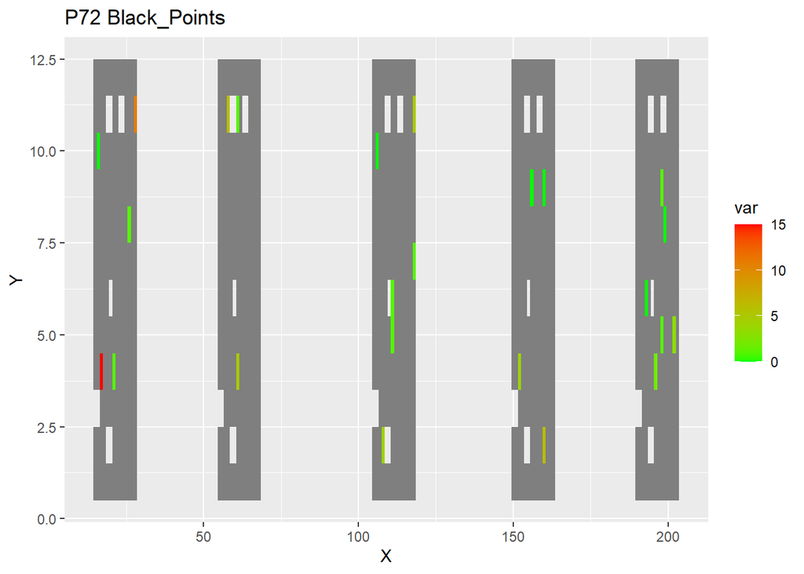

```r
for (i in loop.vector){
  var <- sP72_loop[,i]
  title <- names(sP72_loop[i])
  plot3 <- qplot(X, Y, fill = var, geom = "tile", main = paste("P72", title),
                 data = sP72_clean, xlab = "X", ylab = "Y") +
    scale_fill_gradient(low = "green", high = "red")
  print(plot3)
}
```

Pay attention to the different coordinate of each plot.

# 6 Observing block effects using mixed-effects model

```r
# strain_list <- strain_list <- list(s09AX27_clean, s93JE3_clean, sP72_clean)
# list: strain_list, 1 = 09AX27, 2 = 93JE3, 3 = P72
# strain_list is available in prelim analysis step 2, already saved as .RData
# excluding black points (BP) because it contains many NAs

LP_mix <- list()  # creating an empty list for each model
UN_mix <- list()
US_mix <- list()
for (i in 1:length(strain_list)) {  # loop created for strain i in length
  LP_mix[[i]] <- remlf90(fixed = Laten_24.02.15_gp ~ 1,  # storing mixmod for LP
                         random = ~ Genotype + Block,
                         data = strain_list[[i]],
                         method = "ai")
  UN_mix[[i]] <- remlf90(fixed = total_NbSS ~ 1,  # continue to mixmod for UN
                         random = ~ Genotype + Block,
                         data = strain_list[[i]],
                         method = "ai")
  US_mix[[i]] <- remlf90(fixed = Taill_05.08.20_gp ~ 1,
                         random = ~ Genotype + Block,
                         data = strain_list[[i]],
                         method = "ai")
}

summary(LP_mix[[1]])  # LP mixed model for strain 09AX27
```

```
## Formula: Laten_24.02.15_gp ~ 0 + Intercept + Genotype + Block
##    Data: strain_list[[i]]
##   AIC  BIC logLik
##  2338 2352  -1166
##
## Parameters of special components:
##
##
## Variance components:
##          Estimated variances    S.E.
## Genotype             0.41226 0.07720
## Block                0.04908 0.04031
## Residual             1.04160 0.06471
##
## Fixed effects:
##            value   s.e.
## Intercept 10.583 0.1186
```

## 6.1 Variogram of the residuals (Strain 09AX27 for all traits)

### 6.1.1 Latent Period

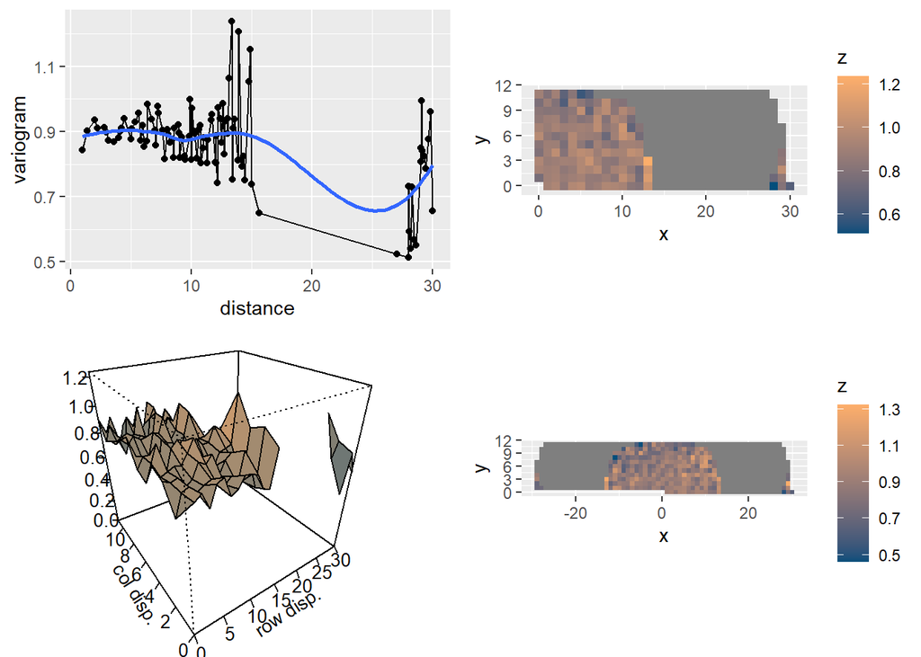

```r
variogram(LP_mix[[1]], coord = s09AX27_clean[, colnames(s09AX27_clean) %in% c("X", "Y")],
          R = 30)
```

Seem that residuals come from environmental variation (related to the coordinates where the genotypes were placed).  
Checking other models (UN and US).

### 6.1.2 Uredinia Number

```r
summary(UN_mix[[1]])  # UN mixmod strain 09AX27
```

```
## Formula: total_NbSS ~ 0 + Intercept + Genotype + Block
##    Data: strain_list[[i]]
##   AIC  BIC logLik
##  4805 4819  -2400
##
## Parameters of special components:
##
##
## Variance components:
##          Estimated variances  S.E.
## Genotype              16.281 2.349
## Block                  1.424 1.107
## Residual              21.342 1.235
##
## Fixed effects:
##            value   s.e.
## Intercept 7.0365 0.6446
```

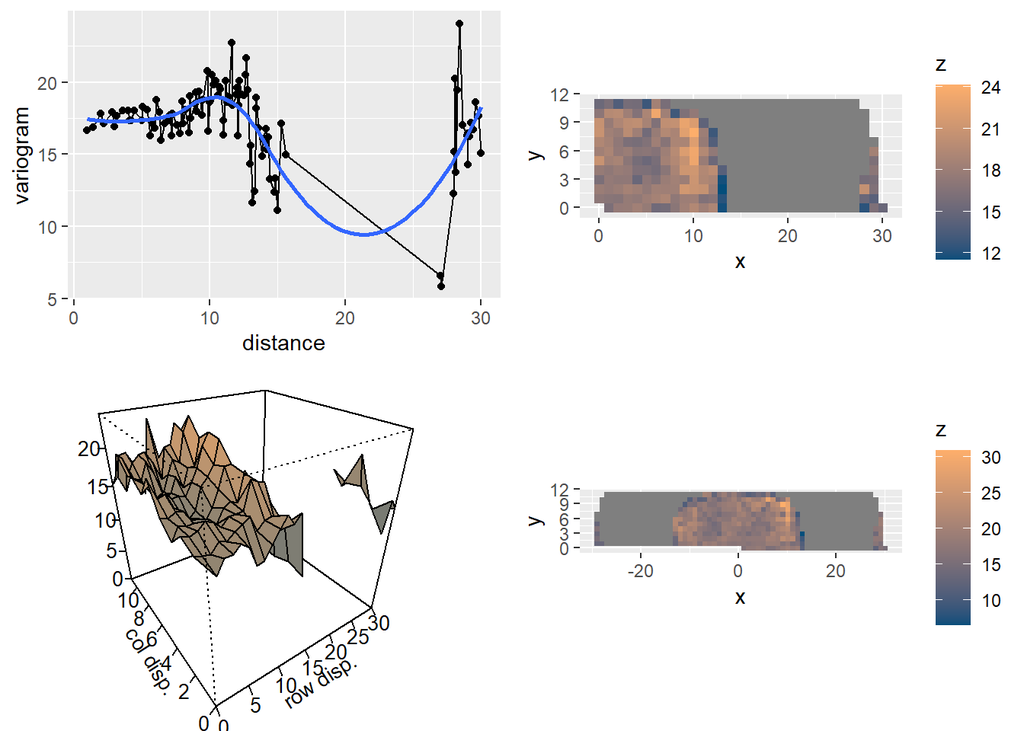

```r
variogram(UN_mix[[1]], coord = s09AX27_clean[, colnames(s09AX27_clean) %in% c("X", "Y")],
          R = 30)
```

### 6.1.3 Uredinia Size

```r
summary(US_mix[[1]])  # US mixmod strain 09AX27
```

```
## Formula: Taill_05.08.20_gp ~ 0 + Intercept + Genotype + Block
##    Data: strain_list[[i]]
##   AIC  BIC logLik
##  2603 2617  -1298
##
## Parameters of special components:
##
##
## Variance components:
##          Estimated variances    S.E.
## Genotype             1.14310 0.15626
## Block                0.03503 0.03014
## Residual             1.12760 0.06542
##
## Fixed effects:
##            value   s.e.
## Intercept 3.1237 0.1253
```

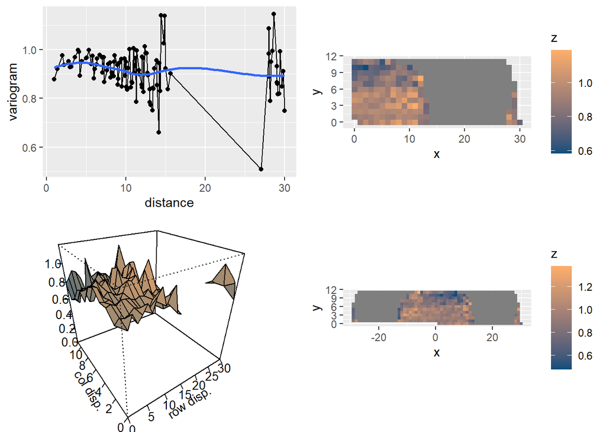

```r
variogram(US_mix[[1]], coord = s09AX27_clean[, colnames(s09AX27_clean) %in% c("X", "Y")],
          R = 30)
```

## 6.2 Variogram of the residuals (Strain 93JE3 for all traits)

### 6.2.1 Latent Period

```r
summary(LP_mix[[2]])  # LP mixmod strain 93JE3
```

```
## Formula: Laten_24.02.15_gp ~ 0 + Intercept + Genotype + Block
##    Data: strain_list[[i]]
##   AIC  BIC logLik
##  1877 1891 -935.7
##
## Parameters of special components:
##
##
## Variance components:
##          Estimated variances    S.E.
## Genotype             0.38546 0.05452
## Block                0.02928 0.02276
## Residual             0.44077 0.02548
##
## Fixed effects:
##            value   s.e.
## Intercept 9.5064 0.0942
```

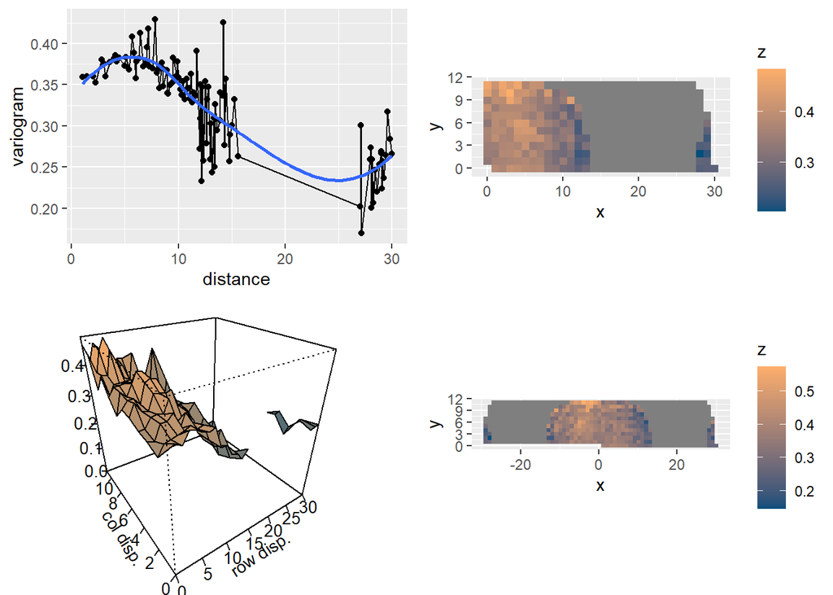

```r
variogram(LP_mix[[2]], coord = s93JE3_clean[, colnames(s93JE3_clean) %in% c("X", "Y")],
          R = 30)
```

### 6.2.2 Uredinia Number

```r
summary(UN_mix[[2]])  # UN mixmod strain 93JE3
```

```
## Formula: total_NbSS ~ 0 + Intercept + Genotype + Block
##    Data: strain_list[[i]]
##   AIC  BIC logLik
##  5372 5386  -2683
##
## Parameters of special components:
##
##
## Variance components:
##          Estimated variances  S.E.
## Genotype              28.217 4.063
## Block                  2.609 2.016
## Residual              38.112 2.157
##
## Fixed effects:
##            value   s.e.
## Intercept 11.443 0.8648
```

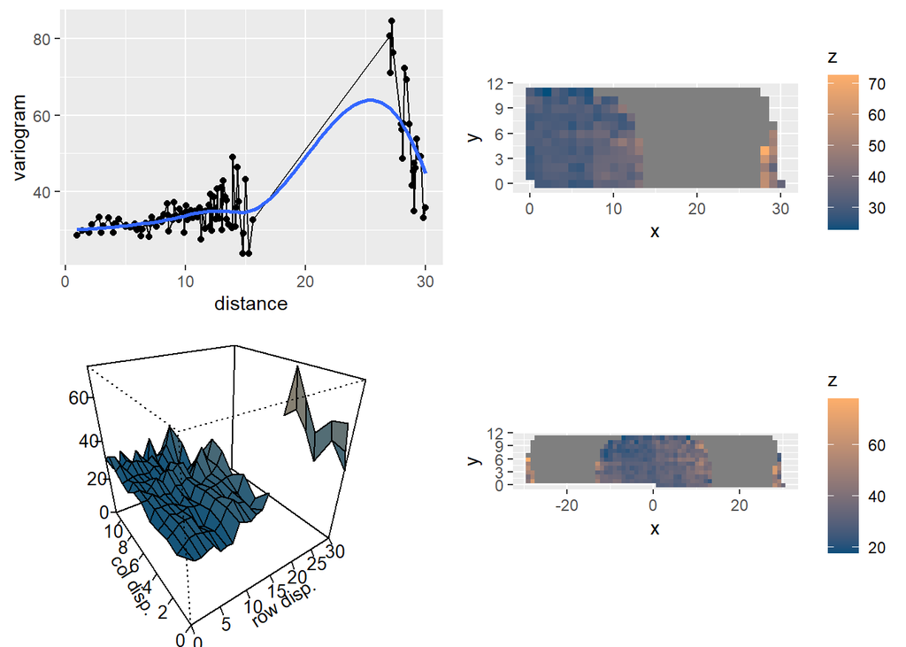

```r
variogram(UN_mix[[2]], coord = s93JE3_clean[, colnames(s93JE3_clean) %in% c("X", "Y")],
          R = 30)
```

### 6.2.3 Uredinia size

```r
summary(US_mix[[2]])  # US mixmod strain 93JE3
```

```
## Formula: Taill_05.08.20_gp ~ 0 + Intercept + Genotype + Block
##    Data: strain_list[[i]]
##   AIC  BIC logLik
##  2274 2288  -1134
##
## Parameters of special components:
##
##
## Variance components:
##          Estimated variances    S.E.
## Genotype             0.89268 0.11574
## Block                0.09837 0.07254
## Residual             0.66533 0.03755
##
## Fixed effects:
##            value   s.e.
## Intercept 3.6612 0.1617
```

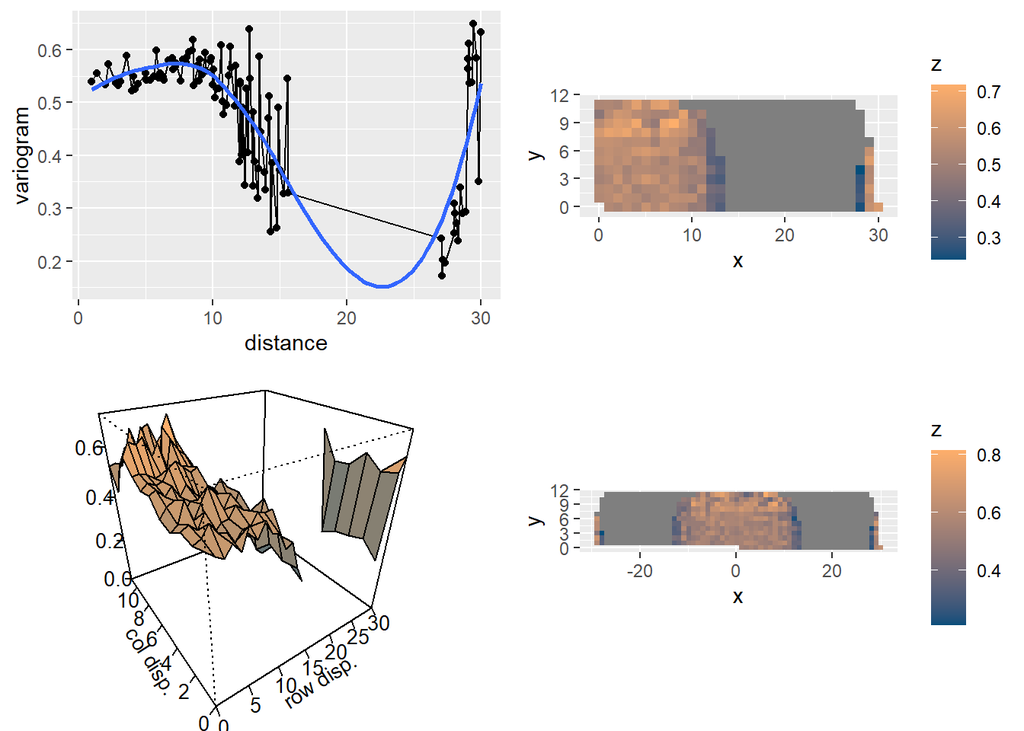

```r
variogram(US_mix[[2]], coord = s93JE3_clean[, colnames(s93JE3_clean) %in% c("X", "Y")],
          R = 30)
```

## 6.3 Variogram of the residuals (Strain P72 for all traits)

### 6.3.1 Latent Period

```r
summary(LP_mix[[3]])  # LP mixmod P72
```

```
## Formula: Laten_24.02.15_gp ~ 0 + Intercept + Genotype + Block
##    Data: strain_list[[i]]
##   AIC  BIC logLik
##  1717 1731 -855.4
##
## Parameters of special components:
##
##
## Variance components:
##          Estimated variances     S.E.
## Genotype            0.403070 0.054410
## Block               0.004325 0.004666
## Residual            0.341900 0.019825
##
## Fixed effects:
##           value   s.e.
## Intercept 9.316 0.0622
```

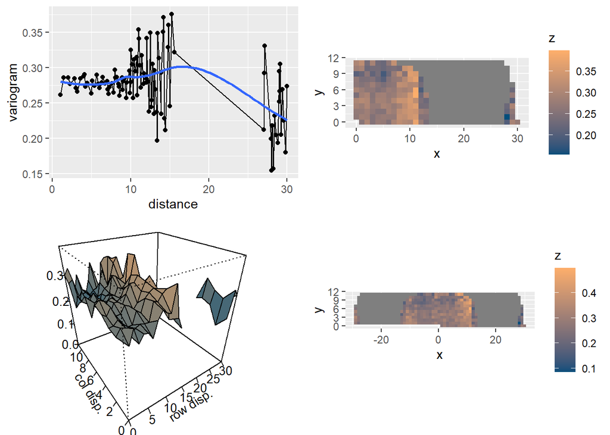

```r
variogram(LP_mix[[3]], coord = sP72_clean[, colnames(sP72_clean) %in% c("X", "Y")],
          R = 30)
```

### 6.3.2 Uredinia Number

```r
summary(UN_mix[[3]])  # UN mixmod strain P72
```

```
## Formula: total_NbSS ~ 0 + Intercept + Genotype + Block
##    Data: strain_list[[i]]
##   AIC  BIC logLik
##  6021 6035  -3008
##
## Parameters of special components:
##
##
## Variance components:
##          Estimated variances   S.E.
## Genotype              77.072 10.582
## Block                  1.764  1.617
## Residual              82.443  4.656
##
## Fixed effects:
##            value   s.e.
## Intercept 17.797 0.9706
```

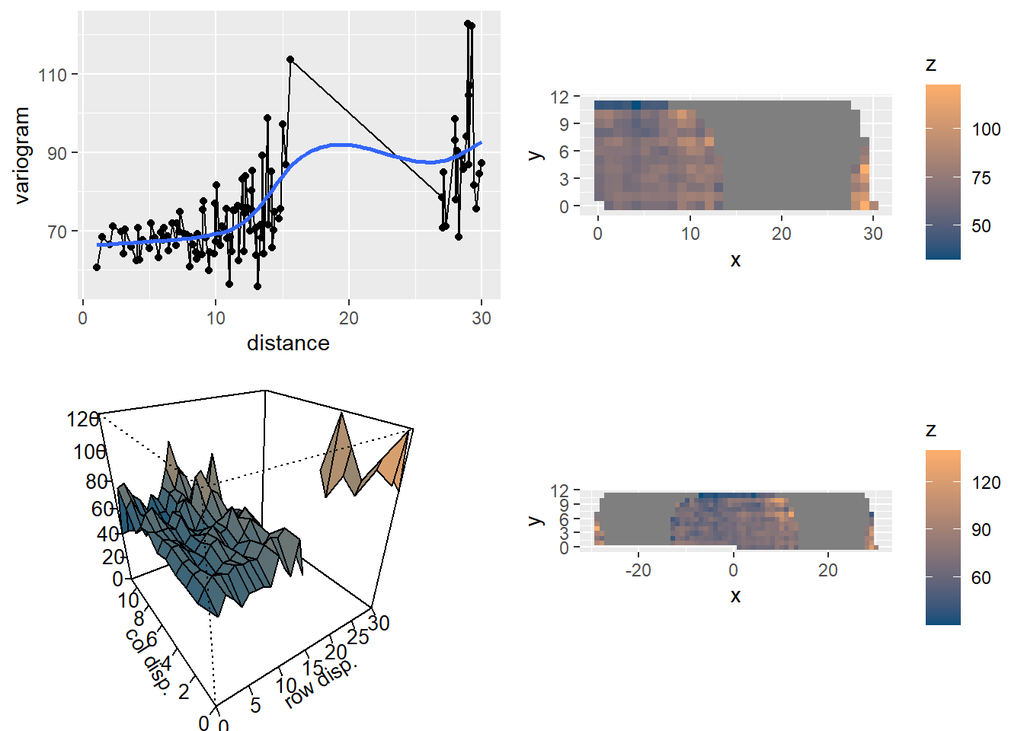

```r
variogram(UN_mix[[3]], coord = sP72_clean[, colnames(sP72_clean) %in% c("X", "Y")],
          R = 30)
```

### 6.3.3 Uredinia Size

```r
summary(US_mix[[3]])  # US mixmod strain P72
```

```
## Formula: Taill_05.08.20_gp ~ 0 + Intercept + Genotype + Block
##    Data: strain_list[[i]]
##   AIC  BIC logLik
##  1894 1908   -944
##
## Parameters of special components:
##
##
## Variance components:
##          Estimated variances    S.E.
## Genotype             0.73376 0.09146
## Block                0.02227 0.01749
## Residual             0.38859 0.02193
##
## Fixed effects:
##            value   s.e.
## Intercept 3.1283 0.0978
```

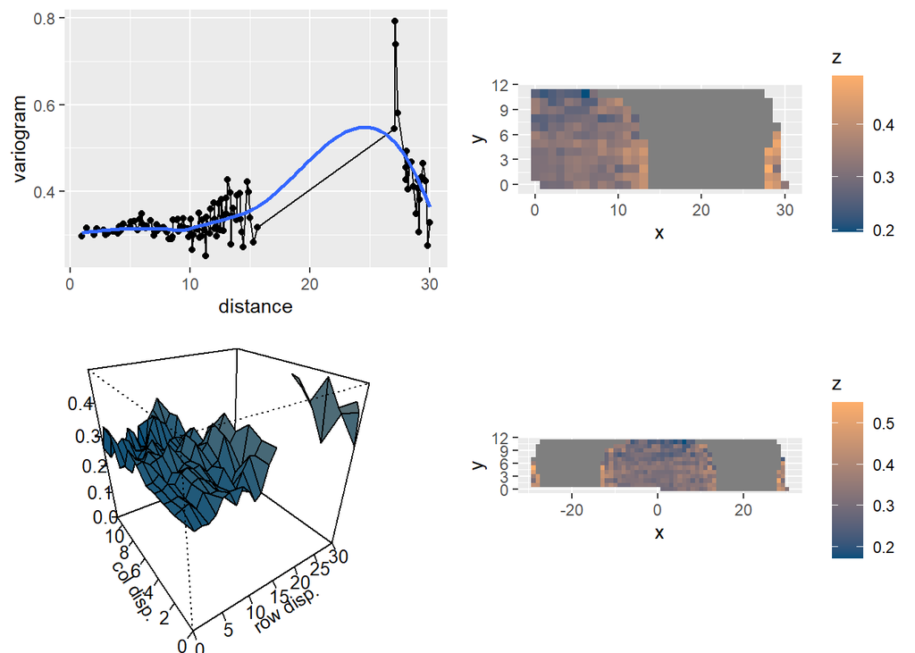

```r
variogram(US_mix[[3]], coord = sP72_clean[, colnames(sP72_clean) %in% c("X", "Y")],
          R = 30)
```

# 7 Adjusting the phenotypes from block effects

Because blocks are a systematic variation that affects the variation in phenotypes, we have to remove them.

```r
# Functions for adjustment ----
fun.coord <- function(X, Y){  # X and Y are coordinates from the dataset
  paste(X, Y, sep = "-")  # Using functions: X = dataset$X, Y = dataset$Y
}

# models: LP_mix (list of 3), UN_mix, US_mix, BP_mix
# LP_mix[[1]] = s09AX27, [[2]] = s93JE3, [[3]] sP72
intercept <- function(mix){  # mix being the name of model
    mix$fixed$Intercept[[1]][1, "value"]  # Example, mix = LP_mix[[1]]
}

BLUP.genot <- function(mix, x){  # x being the name of data frame object
  merge(x, data.frame("Genotype" = rownames(mix$ranef$Genotype[[1]]),
                      "BLUP_Genotype" = mix$ranef$Genotype[[1]]$value),
        by = "Genotype")
}

BLUP.block <- function(mix, x){
  merge(x, data.frame("Block" = rownames(mix$ranef$Block[[1]]),
                      "BLUP¨.block" = mix$ranef$Block[[1]]$value),
        by = "Block")
}


BLUP.resid <- function(data, clean, mix){  # clean and data being the name of data frame object
  merge(data, data.frame("coord" = fun.coord(clean$X, clean$Y),
                      "BLUP_resid" = residuals(mix)),
        by = "coord")
}

adj <- function(x){  # x being the name of data frame object
  x$intercept + x$BLUP_Genotype + x$BLUP_resid
}
```

## 7.1 Adjusting LP

```r
adj_LP <- list(s09AX27_clean[, -c(6:15)],  # creating a list of dataframe to store loop result
               s93JE3_clean[, -c(6:15)],
               sP72_clean[, -c(6:15)])

for (x in 1:length(adj_LP)){  # x in data frame 1 - 3
  adj_LP[[x]]$coord <- fun.coord(X = adj_LP[[x]]$X, Y = adj_LP[[x]]$Y)  # adding coordinates to data frame x
  adj_LP[[x]]$intercept <- intercept(mix = LP_mix[[x]])  # adding intercept extracted from mixmodel
  adj_LP[[x]] <- BLUP.genot(mix = LP_mix[[x]], x = adj_LP[[x]])  # adding BLUP estimates extracted from mixmodel
  adj_LP[[x]] <- BLUP.block(mix = LP_mix[[x]], x= adj_LP[[x]])
  adj_LP[[x]] <- BLUP.resid(data = adj_LP[[x]], clean = adj_LP[[x]],  # adding residuals extracted from mixmodel
                             mix = LP_mix[[x]])
  adj_LP[[x]]$adj_LP <- adj(x = adj_LP[[x]])  # adjusting LP by removing block estimates
}
```

## 7.2 Adjusting UN

```r
adj_UN <- list(s09AX27_clean[, -c(6:15)],
               s93JE3_clean[, -c(6:15)],
               sP72_clean[, -c(6:15)])

for (x in 1:length(adj_UN)){
  adj_UN[[x]]$coord <- fun.coord(adj_UN[[x]]$X, adj_UN[[x]]$Y)
  adj_UN[[x]]$intercept <- intercept(mix = UN_mix[[x]])
  adj_UN[[x]] <- BLUP.genot(UN_mix[[x]], adj_UN[[x]])
  adj_UN[[x]] <- BLUP.block(UN_mix[[x]], adj_UN[[x]])
  adj_UN[[x]] <- BLUP.resid(data = adj_UN[[x]], clean = adj_UN[[x]], mix = UN_mix[[x]])
  adj_UN[[x]]$adj_UN <- adj(adj_UN[[x]])
}
```

## 7.3 Adjusting US

```r
adj_US <- list(s09AX27_clean[, -c(6:15)],
               s93JE3_clean[, -c(6:15)],
               sP72_clean[, -c(6:15)])

for (x in 1:length(adj_US)){
  adj_US[[x]]$coord <- fun.coord(adj_US[[x]]$X, adj_US[[x]]$Y)
  adj_US[[x]]$intercept <- intercept(mix = US_mix[[x]])
  adj_US[[x]] <- BLUP.genot(US_mix[[x]], adj_US[[x]])
  adj_US[[x]] <- BLUP.block(US_mix[[x]], adj_US[[x]])
  adj_US[[x]] <- BLUP.resid(data = adj_US[[x]], clean = adj_US[[x]], mix = US_mix[[x]])
  adj_US[[x]]$adj_US <- adj(adj_US[[x]])
}
```

## 7.4 Extracting the adjusted traits

```r
# Strain 09AX27
adj_s09AX27 <- s09AX27_clean[, -c(6:15)]
adj_s09AX27$Latence <- adj_LP[[1]]$adj_LP
adj_s09AX27$NbSS <- adj_UN[[1]]$adj_UN
adj_s09AX27$Taille <- adj_US[[1]]$adj_US

head(adj_s09AX27)  # preview of the dataset
```

```
##                 Block Strain Genotype X  Y   Latence     NbSS   Taille
## 1 B4est_1_Bloc_1-28x3 09AX27     N-35 1 13  9.560911 6.647067 3.353388
## 2 B4est_1_Bloc_1-28x3 09AX27   NOH-13 2 13 10.644483 3.952688 3.355050
## 3 B4est_1_Bloc_1-28x3 09AX27      N-1 3 13 11.074188 1.411504 2.786913
## 4 B4est_1_Bloc_1-28x3 09AX27    6-A18 4 13 10.812330 6.120470 3.302333
## 5 B4est_1_Bloc_1-28x3 09AX27   SSN-01 5 13 10.613038 9.888991 3.471652
## 6 B4est_1_Bloc_1-28x3 09AX27   BDX-09 6 13  8.828407 1.847917 2.768041
```

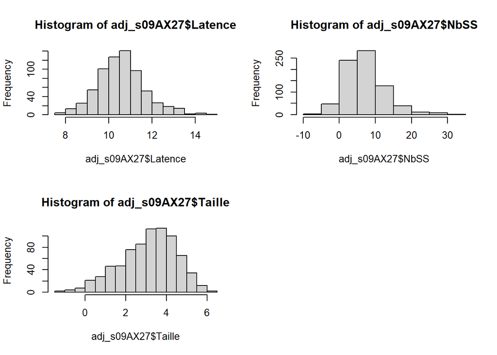

```r
par(mfrow = c(2,2))
hist(adj_s09AX27$Latence)  # distribution of the adjusted traits
hist(adj_s09AX27$NbSS)
hist(adj_s09AX27$Taille)
```

```r
write.table(adj_s09AX27, "adj_traits_s09AX27.txt", sep = "\t", na = "NA",
            quote = FALSE, row.names = FALSE)
```

```r
# Strain 93JE3
adj_s93JE3 <- s93JE3_clean[, -c(6:15)]
adj_s93JE3$Latence <- adj_LP[[2]]$adj_LP
adj_s93JE3$NbSS <- adj_UN[[2]]$adj_UN
adj_s93JE3$Taille <- adj_US[[2]]$adj_US

head(adj_s93JE3)
```

```
##                   Block Strain Genotype X Y   Latence     NbSS    Taille
## 169 B4est_1_Bloc_1-28x3  93JE3     N-35 1 1  9.418226 14.36573 3.1051269
## 170 B4est_1_Bloc_1-28x3  93JE3   NOH-13 2 1 10.732095 14.87693 2.0939435
## 171 B4est_1_Bloc_1-28x3  93JE3      N-1 3 1  9.249911  9.50886 0.6683569
## 172 B4est_1_Bloc_1-28x3  93JE3    6-A18 4 1  9.150708 13.65815 3.8013468
## 173 B4est_1_Bloc_1-28x3  93JE3   SSN-01 5 1  8.836839 21.80744 3.5829619
## 174 B4est_1_Bloc_1-28x3  93JE3   BDX-09 6 1  9.414135 12.97308 3.6272918
```

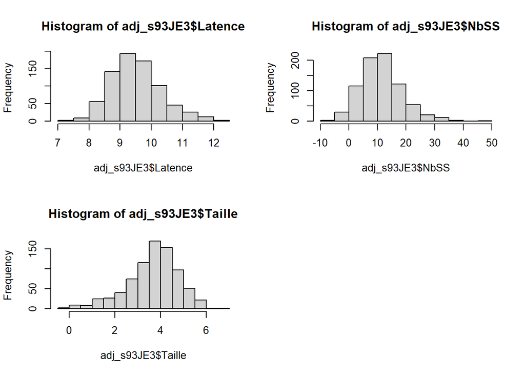

```r
par(mfrow = c(2,2))
hist(adj_s93JE3$Latence)
hist(adj_s93JE3$NbSS)
hist(adj_s93JE3$Taille)
```

```r
write.table(adj_s93JE3, "adj_traits_s93JE3.txt", sep = "\t", na = "NA",
            quote = FALSE, row.names = FALSE)
```

```r
adj_sP72 <- sP72_clean[, -c(6:15)]
adj_sP72$Latence <- adj_LP[[3]]$adj_LP
adj_sP72$NbSS <- adj_UN[[3]]$adj_UN
adj_sP72$Taille <- adj_US[[3]]$adj_US

head(adj_sP72)
```

```
##                   Block Strain Genotype  X Y   Latence      NbSS    Taille
## 337 B4est_1_Bloc_1-28x3    P72     N-35 15 1 11.663830  5.005093 0.6966189
## 338 B4est_1_Bloc_1-28x3    P72   NOH-13 16 1  9.539412  5.602686 2.6859176
## 339 B4est_1_Bloc_1-28x3    P72      N-1 17 1  9.524298  5.449415 0.6115469
## 340 B4est_1_Bloc_1-28x3    P72    6-A18 18 1  9.077248 20.702561 3.2978004
## 341 B4est_1_Bloc_1-28x3    P72   SSN-01 19 1  8.987517 29.779472 2.9518350
## 342 B4est_1_Bloc_1-28x3    P72   BDX-09 20 1  9.404850 21.668897 2.6162258
```

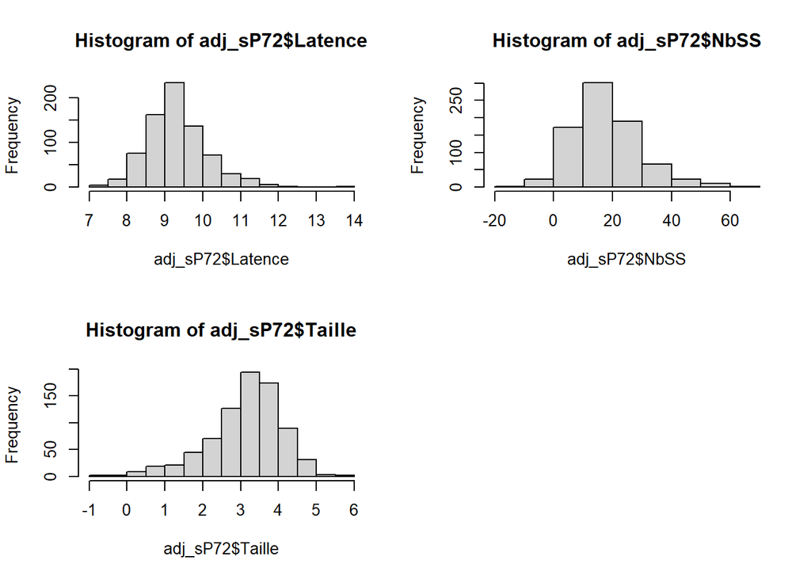

```r
par(mfrow = c(2,2))
hist(adj_sP72$Latence)
hist(adj_sP72$NbSS)
hist(adj_sP72$Taille)
```

```r
write.table(adj_sP72, "adj_traits_sP72.txt", sep = "\t", na = "NA",
            quote = FALSE, row.names = FALSE)
```

# 8 Saving .RData for future analysis

```r
save(s09AX27_clean, s93JE3_clean, sP72_clean, strain_list,
     s09AX27_loop, s93JE3_loop, sP72_loop,
     adj_LP, adj_UN, adj_US,
     adj_s09AX27, adj_s93JE3, adj_sP72,
     file = "prelim_step3.RData")
```